# Software Carpentry - Overview University of Delaware

Software Carpentry Instructors - Josh Herr & Josh Adelman

September 11th - 12th 2014

# Copy This Lecture!

Software Carpentry Overview by [Software Carpentry](http://software-carpentry.net) is licensed under a [Creative Commons Attribution 3.0 Unported License](http://creativecommons.org/licenses/by/3.0/deed.en_US).

# More About Software Carpentry

# History

- Founded by Greg Wilson in 1998, with the goal of teaching scientists how to use supercomputers at LANL.
- Open sourced materials from 2004-present
- SWC is currently minimally funded by the Sloan Foundation & Mozilla Foundation, but all teaching personel are volunteers

# What We Will Teach (We're Flexible here...)

- Unix Command Line Interface (Shell)
- Shell automation
- Version Control
- Python
- Testing
- Some nice python modules (numpy, pandas)

# What We *Actually* Teach

- A computer is just another piece of lab equipment
- Do not be afraid to analyze your data
- Could you be using your time more efficiently?
- Let the computer repeat it - automation!
- Automation leads to a reduction in human errors

*How to THINK like a programmer*

# Who We Teach

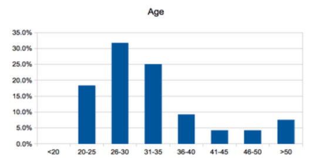

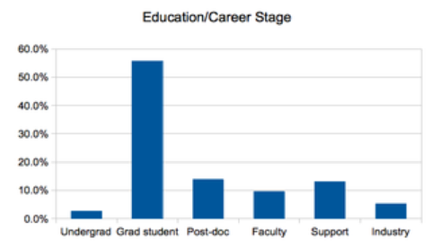

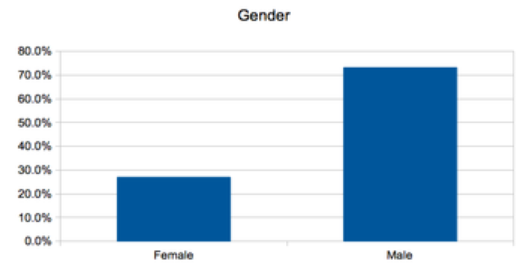

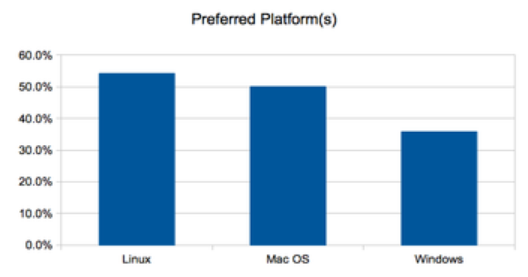

# Who We Are

- Josh Herr (Michigan State University)
- Josh Adelman (University of Pittsburgh)

# Our Goals for You

### We will take you on a tour of:

- Managing and sharing Software, Data, and Manuscripts with **Git**
- Automating things with the **shell**
- Practical Programming with **Python**
- Scientific Computing with Python (numpy, matplotlib)
- Using Git to keep track of changes to your files (collaboration and data provenance)

# Some High-Level Advice (mainly from Greg Wilson)

# Let's try to work in multiple languages

You speak multiple languages when interacting with a computer. Choosing to use a new tool, library, or computer language can be similar to learning a new verbal language:

- There is a high initial startup cost as you learn vocabulary, grammar, and idioms `sum(x*y for x,y in itertools.izip(x_vector, y_vector))`
- But once you have gained some fluency, you will find yourself capable of new things!
- You will learn faster by observing and working with others who are more skilled than you
- Aim for languages and tools that allow you to express your models and manage your data simply.

# Make it work right first, make it fast later.

- "Premature optimization is the root of all evil." -- Donald Knuth
- Directing your attention to making it use less disk / less memory / less time from the start is wrongly directed attention.

# Increase debugging bandwidth

- **REPL (read-eval-print-loop)** environments tighten the coupling between the code you write and the results you see, increasing productivity.
- Development environments and debuggers give you more information at once
- Test your procedures on subsets of your data **so that you learn whether it works faster**

# Don't Repeat Yourself (or Others)

# Automate common actions by saving simple blocks of code into **scripts**

- A script is a set of commands organized into a single file
- The script is the basest unit of scientific programming, you should be comfortable writing these whenever you want to save or otherwise document or repeat your actions
- Use scripts to explore new ideas, they are easy to write and throw away
- **Don't repeat commands into your REPL, save them to a script**

# Refactor commonly used blocks of code into **functions**

- Eventually, you will find that your scripts have a lot of repeated code, or that you are spending a lot of time adjusting parameters at the top of the file
- Refactor out repeated code into **function calls** in your scripts and implement the **function** either in the same file or a separate one
- Be comfortable with the calling and return syntax of your programming language environment, whether it is bash or Python
- **Don't repeat code in scripts, refactor them to functions**

# Group commonly used functions into **libraries**

- If you have to write a lot of software functions, consider designing and releasing a library so that others do not have to share your misfortune
- Check that nobody else has implemented the functionality you need
- If something close exists, it may be worth adapting to your needs if the project is of high quality and suitably licensed
- *Openly licensed non-commercial libraries tend to have a much longer effective lifespan than unreleased codes*
- **Share your code with others, and use their code**

# Reduce Complexity

# Basic strategies

- Use languages and libraries that reduce the complexity of your work
- It is worth installing a complicated or expensive software tool if your computations or model are naturally expressed with it
- Always look for opportunities to write **less** code
  - you will have to do less initial work (sometimes)
  - you will introduce less bugs
  - your code will be easier to understand and maintain
- Keep individual functions short, single-purpose, possible to be confident in festooning.

# Back up your data!

# Use version control for checkpointing and collaboration

- use local version control software to checkpoint personal code development
- checkpointing your work encourages wild ideas and late-night coding sessions
- you can easily restore back in the morning if it was a bad idea
- use **distributed version control** to collaborate with others
- We advocate *Git*, but you may be stuck with whatever your group uses

# Verify and Validate your Code

# Principles of verification and validation

- **verification** - is your code correctly written?
- Be paranoid.
- test small things!
- test that what you assume is TRUE is in fact so.
- test frameworks can help you verify your code
- **validation** - do your computations accurately model the phenomena in question?
- not a good candidate for automation. (Not sad at all)

# Document your computational work

- Save every bit of code you use for generating publishable results
- Document and comment your code for yourself as if you will need to understand it in 6 months
- use README files liberally
- as well as file-level, function-level, and inline documentation
- If any piece of code is too complex to easily describe, consider refactoring it

# Super Simplified Schedule

- Today
- **9:00-12:00** The Shell
- **1:00-4:30** Python
- Tomorrow
- **9:00-12:00** Version control with Git
- **1:00-4:30** More Advanced Python

# Luke, Use the stickies...

# Green post it note means I have completed the task or am not having trouble.

# Red post it note means I need some help but am still working on the problem.

# At the end of the day, write one thing you liked on the green and one thing you would like to see improved on the red - we'll respond!

# Closing Thoughts

# You sometimes need geeks. You never need dorks.

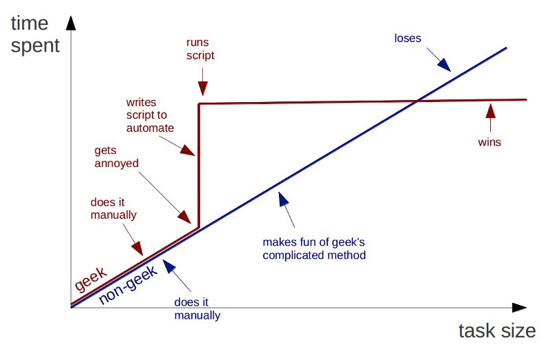